# Projet 9 : Predire une consommation d'electricité

```python
# Importation des  modules et librairies  pour  la data science
import sys
!{sys.executable} -m pip install pmdarima
import pandas as  pd
import  numpy as  np
import matplotlib.pyplot as  plt
from matplotlib.collections import LineCollection
%matplotlib inline
import seaborn as sns
sns.set_style('darkgrid')
import plotly.express as px

import pmdarima as pm
from sklearn import decomposition
from sklearn import preprocessing
from sklearn.linear_model import LogisticRegression
from sklearn.model_selection import train_test_split
from sklearn.preprocessing import StandardScaler
from sklearn.linear_model import LogisticRegression
from sklearn.metrics import confusion_matrix
from sklearn.metrics import classification_report,accuracy_score
from matplotlib.colors import ListedColormap
from mpl_toolkits.mplot3d import Axes3D
from functions import *
import scipy.stats as st
from scipy.stats import ks_2samp
from sklearn.cluster import KMeans
from scipy.cluster.hierarchy import dendrogram, linkage, fcluster
import statsmodels.formula.api as smf
import statsmodels.api as sm
import math as ma
from statsmodels.formula.api import ols
from statsmodels.stats.outliers_influence import variance_inflation_factor

from collections import Counter
import warnings
warnings.filterwarnings("ignore")
from sklearn import linear_model
from statsmodels.tsa.seasonal import seasonal_decompose
from statsmodels.tsa.api import ExponentialSmoothing
from statsmodels.tsa.statespace.sarimax import SARIMAX
from statsmodels.graphics.tsaplots import plot_acf, plot_pacf
from statsmodels.tsa.seasonal import seasonal_decompose
from statsmodels.tsa.arima_model import ARIMA

from pmdarima.arima.utils import ndiffs
from pmdarima import auto_arima

#Une fois  les  modules  importés  nous allons  charger  les données
```

# Scenario du projet

Employé chez Enercoop , une entreprise specialisée dans la production et commercialisation de produits d'energies renouvelables , il nous est demandé de predire la consommation d'electricité en tenant compte de certains facteurs. Cette predicton s'avere difficile car la demande est assujetie à certains aléas climatiques que sont la temperature , la meteo etc. Pour ce projet 9 qui porte sur la modelisation des series temporelles , nous devons donc nous appuyer sur des objets python de type SARIMA et autres pour realiser cette modelisation **Objectif du projet**:

Prédire une demande en énergie car elle n'est pas stockable, si on en crée trop, elle est perdue. A l'aide des **températures de météo** et des **consommations en électricité passées (2009-2021)**, il faut pouvoir prédire la **demande future** à l'aide d'un **modèle de Machine Learning**.

On se trouve dans un contexte de **time series**

# Les données

Nous disposons de deux fichiers qui indiquent la consommation d'electricité mensuelle et la meteo de stations regionales de meteo annuelle.

```python
#Chargement des fichiers
dfen = pd.read_csv('V2eCO2mix_RTE_energie_M.csv',parse_dates=True, dayfirst=True,sep = ';')
dfen.info()
dfen
```

```
<class 'pandas.core.frame.DataFrame'>
RangeIndex: 936 entries, 0 to 935
Data columns (total 22 columns):
 #   Column                                    Non-Null Count  Dtype
---  ------                                    --------------  -----
 0   Mois                                      936 non-null    object
 1   QualitÈ                                   936 non-null    object
 2   Territoire                                936 non-null    object
 3   Production totale                         936 non-null    int64
 4   Production nuclÈaire                      576 non-null    float64
 5   Production thermique totale               936 non-null    int64
 6   Production thermique charbon              625 non-null    float64
 7   Production thermique fioul                936 non-null    int64
 8   Production thermique gaz                  936 non-null    int64
 9   Production hydraulique                    936 non-null    int64
 10  Production Èolien                         936 non-null    int64
 11  Production solaire                        936 non-null    int64
 12  Production bioÈnergies                    936 non-null    int64
 13  Consommation totale                       936 non-null    int64
 14  Solde exportateur                         936 non-null    int64
 15  Echanges export                           72 non-null     float64
 16  Echanges import                           72 non-null     float64
 17  Echanges avec le Royaume-Uni              72 non-null     float64
 18  Echanges avec l'Espagne                   72 non-null     float64
 19  Echanges avec l'Italie                    72 non-null     float64
 20  Echanges avec la Suisse                   72 non-null     float64
 21  Echanges avec l'Allemagne et la Belgique  72 non-null     float64
dtypes: float64(9), int64(10), object(3)
memory usage: 161.0+ KB
```

|  | Mois | QualitÈ | Territoire | Production totale | Production nuclÈaire | Production thermique totale | Production thermique charbon | Production thermique fioul | Production thermique gaz | Production hydraulique | ... | Production bioÈnergies | Consommation totale | Solde exportateur | Echanges export | Echanges import | Echanges avec le Royaume-Uni | Echanges avec l'Espagne | Echanges avec l'Italie | Echanges avec la Suisse | Echanges avec l'Allemagne et la Belgique |
| --- | --- | --- | --- | --- | --- | --- | --- | --- | --- | --- | --- | --- | --- | --- | --- | --- | --- | --- | --- | --- | --- |
| 0 | 2014-01 | DonnÈes dÈfinitives | Grand-Est | 10126 | 8071.0 | 740 | 399.0 | 0 | 340 | 712 | ... | 53 | 4594 | 5431 | NaN | NaN | NaN | NaN | NaN | NaN | NaN |
| 1 | 2014-01 | DonnÈes dÈfinitives | Nouvelle-Aquitaine | 4688 | 3871.0 | 77 | NaN | 0 | 77 | 520 | ... | 89 | 4501 | 187 | NaN | NaN | NaN | NaN | NaN | NaN | NaN |
| 2 | 2014-01 | DonnÈes dÈfinitives | Auvergne-RhÙne-Alpes | 13001 | 9578.0 | 139 | 0.0 | 35 | 103 | 3116 | ... | 74 | 6693 | 5858 | NaN | NaN | NaN | NaN | NaN | NaN | NaN |
| 3 | 2014-01 | DonnÈes dÈfinitives | Bourgogne-Franche-ComtÈ | 301 | NaN | 89 | 0.0 | 0 | 90 | 153 | ... | 13 | 2158 | -1857 | NaN | NaN | NaN | NaN | NaN | NaN | NaN |
| 4 | 2014-01 | DonnÈes dÈfinitives | Bretagne | 345 | NaN | 60 | NaN | 0 | 59 | 57 | ... | 21 | 2390 | -2050 | NaN | NaN | NaN | NaN | NaN | NaN | NaN |
| ... | ... | ... | ... | ... | ... | ... | ... | ... | ... | ... | ... | ... | ... | ... | ... | ... | ... | ... | ... | ... | ... |
| 931 | 2019-12 | DonnÈes dÈfinitives | Occitanie | 3901 | 1578.0 | 67 | NaN | 0 | 67 | 1690 | ... | 68 | 3708 | -2 | NaN | NaN | NaN | NaN | NaN | NaN | NaN |
| 932 | 2019-12 | DonnÈes dÈfinitives | Normandie | 3702 | 3013.0 | 362 | 49.0 | 25 | 288 | 12 | ... | 44 | 2841 | 860 | NaN | NaN | NaN | NaN | NaN | NaN | NaN |
| 933 | 2019-12 | DonnÈes dÈfinitives | Hauts-de-France | 5544 | 3214.0 | 917 | 0.0 | 6 | 911 | 1 | ... | 94 | 4819 | 725 | NaN | NaN | NaN | NaN | NaN | NaN | NaN |
| 934 | 2019-12 | DonnÈes dÈfinitives | PACA | 1952 | NaN | 648 | 0.0 | 18 | 630 | 1139 | ... | 76 | 3925 | -1974 | NaN | NaN | NaN | NaN | NaN | NaN | NaN |
| 935 | 2019-12 | DonnÈes dÈfinitives | Pays-de-la-Loire | 747 | NaN | 406 | 102.0 | 13 | 291 | 2 | ... | 40 | 2819 | -2072 | NaN | NaN | NaN | NaN | NaN | NaN | NaN |

936 rows × 22 columns

```python
dfen.Territoire.unique()
```

```
array(['Grand-Est', 'Nouvelle-Aquitaine', 'Auvergne-RhÙne-Alpes',
       'Bourgogne-Franche-ComtÈ', 'Bretagne', 'Centre-Val de Loire',
       'France', 'Ile-de-France', 'Occitanie', 'Normandie',
       'Hauts-de-France', 'PACA', 'Pays-de-la-Loire'], dtype=object)
```

Cette table indique les productions d'electricité mensuelles de plusieurs années et leurs consommations selon le regions ou le territoire national. Nous y remarquons des irregularités au niveau des types de variables qu'il faudra caster . Notamment la colonne representant le temps.

```python
#Chargeons  la seconde table  de DJU
dju = pd.read_csv('dju_chauff_V1.csv', sep = ';')
dju.rename(columns = {'Unnamed: 0' :'Annee'} , inplace =True)
dju.info()
dju.head()
```

```
<class 'pandas.core.frame.DataFrame'>
RangeIndex: 6 entries, 0 to 5
Data columns (total 14 columns):
 #   Column  Non-Null Count  Dtype
---  ------  --------------  -----
 0   Annee   6 non-null      int64
 1   JAN     6 non-null      float64
 2   FÉV     6 non-null      float64
 3   MAR     6 non-null      float64
 4   AVR     6 non-null      float64
 5   MAI     6 non-null      float64
 6   JUN     6 non-null      float64
 7   JUI     6 non-null      float64
 8   AOÛ     6 non-null      float64
 9   SEP     6 non-null      float64
 10  OCT     6 non-null      float64
 11  NOV     6 non-null      float64
 12  DÉC     6 non-null      float64
 13  Total   6 non-null      float64
dtypes: float64(13), int64(1)
memory usage: 800.0 bytes
```

|  | Annee | JAN | FÉV | MAR | AVR | MAI | JUN | JUI | AOÛ | SEP | OCT | NOV | DÉC | Total |
| --- | --- | --- | --- | --- | --- | --- | --- | --- | --- | --- | --- | --- | --- | --- |
| 0 | 2019 | 499.9 | 366.4 | 327.7 | 275.6 | 229.8 | 60.3 | 24.2 | 27.9 | 101.7 | 194.7 | 370.0 | 406.3 | 2884.3 |
| 1 | 2018 | 376.0 | 506.1 | 407.5 | 196.3 | 119.6 | 44.7 | 1.5 | 34.2 | 103.9 | 204.3 | 356.0 | 417.5 | 2767.4 |
| 2 | 2017 | 581.9 | 357.0 | 305.0 | 318.5 | 144.0 | 41.8 | 30.8 | 43.8 | 143.0 | 199.0 | 383.8 | 434.7 | 2983.1 |
| 3 | 2016 | 454.5 | 392.1 | 412.7 | 299.9 | 174.4 | 70.9 | 32.6 | 37.2 | 75.3 | 273.4 | 378.1 | 496.5 | 3097.4 |
| 4 | 2015 | 483.3 | 437.3 | 383.8 | 271.2 | 194.7 | 72.8 | 37.4 | 29.4 | 151.3 | 263.0 | 275.9 | 327.3 | 2927.3 |

Cette table indique les observation de degre jour unifié. On pourrait traduit cet indicateur comme les deficits à combler pour avoir une temperature de 19 degre . Cet indicateur varie car le besoin varie selon la meteo notamment s'il fait chaud , froid . Par exemple avec un degre de 5 on aura besoin de plus de dju qu'avec un degré de 15 .

**Transformation de la table du deficit**

Nous allons renommer les colonnes en les remplacant par des nombres . Ensuite nous allons fusionner les colonnes de sorte à apparier les mois sur les années avec la fonction .melt

```python
# Renommer les colonnes
# Ici les mois on les prend en tant que string
dju = dju.rename(columns={"JAN":"1" ,"FÉV":"2","MAR":'3','AVR':'4','MAI':'5','JUN':'6','JUI':'7','AOÛ':'8','SEP':'9','OCT':'10','NOV':'11','DÉC':'12'})

# On supprime la colonne total
chauffage_mensuel = dju.drop(columns = 'Total')
chauffage_mensuel.head()
```

|  | Annee | 1 | 2 | 3 | 4 | 5 | 6 | 7 | 8 | 9 | 10 | 11 | 12 |
| --- | --- | --- | --- | --- | --- | --- | --- | --- | --- | --- | --- | --- | --- |
| 0 | 2019 | 499.9 | 366.4 | 327.7 | 275.6 | 229.8 | 60.3 | 24.2 | 27.9 | 101.7 | 194.7 | 370.0 | 406.3 |
| 1 | 2018 | 376.0 | 506.1 | 407.5 | 196.3 | 119.6 | 44.7 | 1.5 | 34.2 | 103.9 | 204.3 | 356.0 | 417.5 |
| 2 | 2017 | 581.9 | 357.0 | 305.0 | 318.5 | 144.0 | 41.8 | 30.8 | 43.8 | 143.0 | 199.0 | 383.8 | 434.7 |
| 3 | 2016 | 454.5 | 392.1 | 412.7 | 299.9 | 174.4 | 70.9 | 32.6 | 37.2 | 75.3 | 273.4 | 378.1 | 496.5 |
| 4 | 2015 | 483.3 | 437.3 | 383.8 | 271.2 | 194.7 | 72.8 | 37.4 | 29.4 | 151.3 | 263.0 | 275.9 | 327.3 |

```python
#Nous allons dépivoté Les colonnes mois afin de créer une seule colonne mois
#https://pandas.pydata.org/docs/reference/api/pandas.melt.html
chauffage_mensuelv = chauffage_mensuel.melt(id_vars = ["Annee"], value_vars=["1","2","3","4","5","6","7","8","9","10","11","12"]).rename(columns={"variable":"Mois", "value":"dju"})
chauffage_mensuelv
```

|  | Annee | Mois | dju |
| --- | --- | --- | --- |
| 0 | 2019 | 1 | 499.9 |
| 1 | 2018 | 1 | 376.0 |
| 2 | 2017 | 1 | 581.9 |
| 3 | 2016 | 1 | 454.5 |
| 4 | 2015 | 1 | 483.3 |
| ... | ... | ... | ... |
| 67 | 2018 | 12 | 417.5 |
| 68 | 2017 | 12 | 434.7 |
| 69 | 2016 | 12 | 496.5 |
| 70 | 2015 | 12 | 327.3 |
| 71 | 2014 | 12 | 447.7 |

72 rows × 3 columns

```python
#Transformons  la table de sorte à avoir  les années et  mois dans  une colonne
chauffage_mensuelv['date'] = pd.to_datetime(chauffage_mensuelv.Annee.astype(str) + '-' + chauffage_mensuelv.Mois.astype(str))
chauffage_mensuelv
```

|  | Annee | Mois | dju | date |
| --- | --- | --- | --- | --- |
| 0 | 2019 | 1 | 499.9 | 2019-01-01 |
| 1 | 2018 | 1 | 376.0 | 2018-01-01 |
| 2 | 2017 | 1 | 581.9 | 2017-01-01 |
| 3 | 2016 | 1 | 454.5 | 2016-01-01 |
| 4 | 2015 | 1 | 483.3 | 2015-01-01 |
| ... | ... | ... | ... | ... |
| 67 | 2018 | 12 | 417.5 | 2018-12-01 |
| 68 | 2017 | 12 | 434.7 | 2017-12-01 |
| 69 | 2016 | 12 | 496.5 | 2016-12-01 |
| 70 | 2015 | 12 | 327.3 | 2015-12-01 |
| 71 | 2014 | 12 | 447.7 | 2014-12-01 |

72 rows × 4 columns

```python
#Restriction de la table
chauffage_mensuelv = chauffage_mensuelv[['date','dju']]
chauffage_mensuelv
```

|  | date | dju |
| --- | --- | --- |
| 0 | 2019-01-01 | 499.9 |
| 1 | 2018-01-01 | 376.0 |
| 2 | 2017-01-01 | 581.9 |
| 3 | 2016-01-01 | 454.5 |
| 4 | 2015-01-01 | 483.3 |
| ... | ... | ... |
| 67 | 2018-12-01 | 417.5 |
| 68 | 2017-12-01 | 434.7 |
| 69 | 2016-12-01 | 496.5 |
| 70 | 2015-12-01 | 327.3 |
| 71 | 2014-12-01 | 447.7 |

72 rows × 2 columns

```python
chauffage_mensuelv.isna().sum()
```

```
date    0
dju     0
dtype: int64
```

```python
# parametre  de configuration de nos graphiques
from pylab import rcParams
rcParams['figure.figsize'] = 20, 10
```

```python
df = dfen[dfen['Territoire'] == 'Grand-Est']
dfv = df[['Mois','Consommation totale']]
dfv
```

|  | Mois | Consommation totale |
| --- | --- | --- |
| 0 | 2014-01 | 4594 |
| 13 | 2014-02 | 4173 |
| 26 | 2014-03 | 4075 |
| 39 | 2014-04 | 3523 |
| 52 | 2014-05 | 3447 |
| ... | ... | ... |
| 871 | 2019-08 | 3011 |
| 884 | 2019-09 | 3225 |
| 897 | 2019-10 | 3758 |
| 910 | 2019-11 | 4218 |
| 923 | 2019-12 | 4453 |

72 rows × 2 columns

```python
dfv["Mois"] = pd.to_datetime(dfv["Mois"])
dfv.rename(columns = {'Mois' :'date'}, inplace  =  True)
dfv
```

|  | date | Consommation totale |
| --- | --- | --- |
| 0 | 2014-01-01 | 4594 |
| 13 | 2014-02-01 | 4173 |
| 26 | 2014-03-01 | 4075 |
| 39 | 2014-04-01 | 3523 |
| 52 | 2014-05-01 | 3447 |
| ... | ... | ... |
| 871 | 2019-08-01 | 3011 |
| 884 | 2019-09-01 | 3225 |
| 897 | 2019-10-01 | 3758 |
| 910 | 2019-11-01 | 4218 |
| 923 | 2019-12-01 | 4453 |

72 rows × 2 columns

```python
#Fusionnons les deux tables
data = pd.merge(dfv,chauffage_mensuelv , on  = 'date' ,how = 'inner')
data
```

|  | date | Consommation totale | dju |
| --- | --- | --- | --- |
| 0 | 2014-01-01 | 4594 | 414.4 |
| 1 | 2014-02-01 | 4173 | 361.5 |
| 2 | 2014-03-01 | 4075 | 350.4 |
| 3 | 2014-04-01 | 3523 | 236.9 |
| 4 | 2014-05-01 | 3447 | 182.5 |
| ... | ... | ... | ... |
| 67 | 2019-08-01 | 3011 | 27.9 |
| 68 | 2019-09-01 | 3225 | 101.7 |
| 69 | 2019-10-01 | 3758 | 194.7 |
| 70 | 2019-11-01 | 4218 | 370.0 |
| 71 | 2019-12-01 | 4453 | 406.3 |

72 rows × 3 columns

```python
#Statistiques descriptives de l'échantillon
data.describe().T
```

|  | count | mean | std | min | 25% | 50% | 75% | max |
| --- | --- | --- | --- | --- | --- | --- | --- | --- |
| Consommation totale | 72.0 | 3826.847222 | 563.916502 | 2952.0 | 3345.750 | 3749.50 | 4248.500 | 5307.0 |
| dju | 72.0 | 241.938889 | 158.039912 | 1.5 | 81.975 | 249.95 | 376.525 | 581.9 |

```python
#Mettons en indexe la colonne date
data.set_index('date',inplace = True)
```

```python
data.info()
```

```
<class 'pandas.core.frame.DataFrame'>
DatetimeIndex: 72 entries, 2014-01-01 to 2019-12-01
Data columns (total 2 columns):
 #   Column               Non-Null Count  Dtype
---  ------               --------------  -----
 0   Consommation totale  72 non-null     int64
 1   dju                  72 non-null     float64
dtypes: float64(1), int64(1)
memory usage: 1.7 KB
```

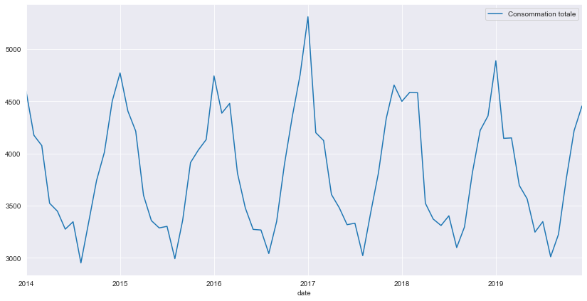

```python
#Tracons uniquement sa representation
data.plot(y= ["Consommation totale"],figsize=(14,7))
```

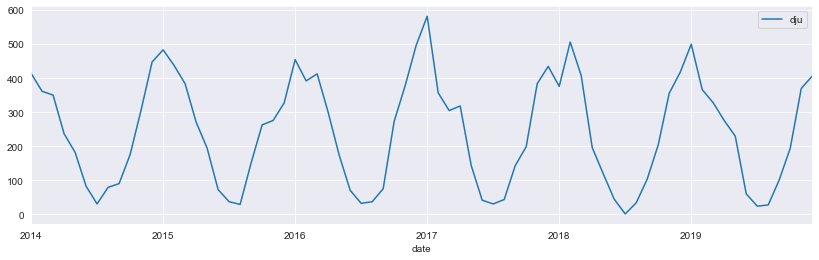

```python
#Representation graphique  du  deficit  d'electricité  dju
data.plot(y= "dju",figsize=(14,4))
```

La tables des degres jours unifiés iindique un calcul chauffage ou climatisation sur une période, une station météo et un seuil de température donnés.Le degré jour est une valeur représentative de l’écart entre la température d’une journée donnée et un seuil de température préétabli (18 °C dans le cas des DJU ou Degré Jour Unifié). Sommés sur une période, ils permettent de calculer les besoins de chauffage et de climatisation d’un bâtiment. Nous nous sommes basés sur 19 degres et la modalité chauffage uniquement.

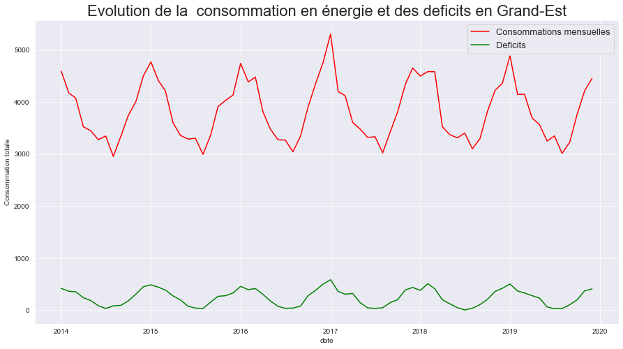

```python
fig = plt.figure(figsize=(15,8))
sns.lineplot(data = data, x= data.index,  y="Consommation totale", color="Red",label='Consommations mensuelles')
sns.lineplot(data = data, x= data.index,  y="dju", color="Green",label='Deficits')
plt.title("Evolution de la  consommation en énergie et des deficits en Grand-Est", fontsize=22)
plt.legend(fontsize=13, loc='best')
plt.savefig('Distribution des consommations et  deficits du  Grand Est.jpg')
plt.show()
```

Nous avons maintenant une table synthetisee que nous pourrons joindre à la premiere table

# Choix pour constituer la table de modelisation

Je choisiss de garder toutes les années à l'exception de 2021, 2020 , 2009,2010,2011,2012 . Ainsi je prendrai en compte les années 2019 ,2018,2017,2016,2015,2014. Je ferai un filtre pour garder que ses donnees et aussi je ne garderai que la variable de consommation totale en excluant la france comme territoire. Je garderai donc que la region du grand est dont j'ai choisi pour la tble des degres jours unifies . Mon choix de selection des années repond au fait que la pandemie de Covid 19 a eu des impacts importants sur les lignes de production et aussi sur les consommations des menages de l'energie.

Nous avons une table rstreinte et filtree sur certaines années et que sur la regio grand est qui est la region cible à travers laquelle nous avons telechargé les DJU . Nous pouvons visualiser les observations des deux variables selon le temps

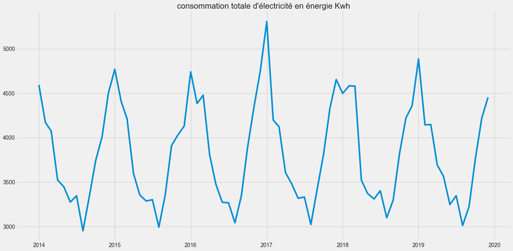

```python
#Representation graphique
%pylab inline
pylab.style.use('fivethirtyeight')
plt.figure(figsize=(20, 10))
plt.plot(data['Consommation totale'])
plt.title("consommation totale d'électricité en énergie Kwh")
plt.savefig("conso_elect.png")
plt.show()
```

**Commentaire du graphique**

# Q1:Correction de la variation saisonniere par regression lineaire

```python
#Notre table
data.rename(columns = {'Consommation totale': 'consoelect'} , inplace  = True)
data
```

| date | consoelect | dju |
| --- | --- | --- |
| 2014-01-01 | 4594 | 414.4 |
| 2014-02-01 | 4173 | 361.5 |
| 2014-03-01 | 4075 | 350.4 |
| 2014-04-01 | 3523 | 236.9 |
| 2014-05-01 | 3447 | 182.5 |
| ... | ... | ... |
| 2019-08-01 | 3011 | 27.9 |
| 2019-09-01 | 3225 | 101.7 |
| 2019-10-01 | 3758 | 194.7 |
| 2019-11-01 | 4218 | 370.0 |
| 2019-12-01 | 4453 | 406.3 |

72 rows × 2 columns

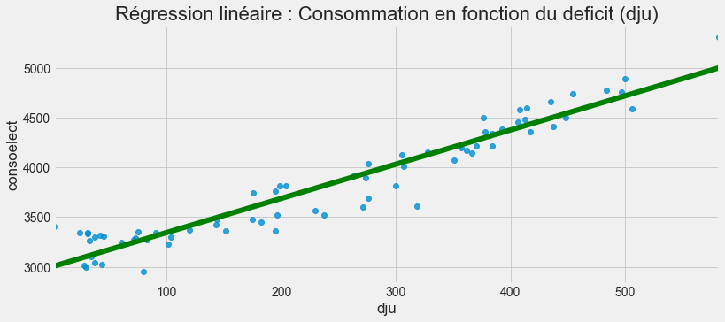

```python
#Representons la droite de regression de  notre echantillon
fig = plt.figure(figsize=(12,5))
ax = sns.regplot(data=data, x="dju", y="consoelect", robust=True, ci=None, line_kws={"color":"green"})
plt.title("Régression linéaire : Consommation en fonction du deficit (dju)", fontsize=22)
plt.show()
```

```python
#Faire une régression linéaire entre les consommations et les déficits:
reg_simp = smf.ols('consoelect ~ dju', data = data).fit()
print(reg_simp.summary())
```

```
                            OLS Regression Results
==============================================================================
Dep. Variable:             consoelect   R-squared:                       0.916
Model:                            OLS   Adj. R-squared:                  0.915
Method:                 Least Squares   F-statistic:                     766.1
Date:                Mon, 28 Feb 2022   Prob (F-statistic):           1.98e-39
Time:                        16:43:03   Log-Likelihood:                -468.48
No. Observations:                  72   AIC:                             941.0
Df Residuals:                      70   BIC:                             945.5
Df Model:                           1
Covariance Type:            nonrobust
==============================================================================
                 coef    std err          t      P>|t|      [0.025      0.975]
------------------------------------------------------------------------------
Intercept   3000.4907     35.587     84.315      0.000    2929.516    3071.466
dju            3.4156      0.123     27.679      0.000       3.169       3.662
==============================================================================
Omnibus:                        1.858   Durbin-Watson:                   1.882
Prob(Omnibus):                  0.395   Jarque-Bera (JB):                1.241
Skew:                          -0.294   Prob(JB):                        0.538
Kurtosis:                       3.262   Cond. No.                         530.
==============================================================================

Notes:
[1] Standard Errors assume that the covariance matrix of the errors is correctly specified.
```

Nous obtenons un coefficient de termination ajusté de 0.92 . Cet indicateur est tres bien et montre comme l'approche graphique que les deux variables sont tres correlées.la p valeur de variable independante aussi est tres significative au seil de 5%. Nous allons tester d'autres indicateurs comme les residus et la normalité de celle ci .

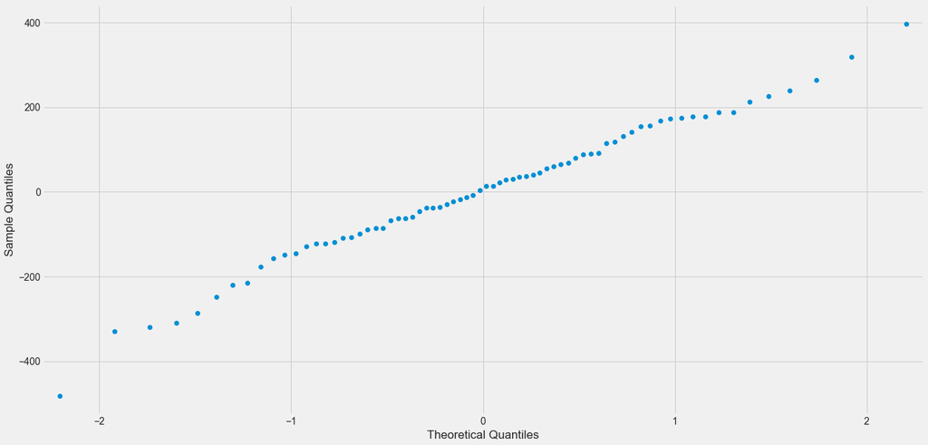

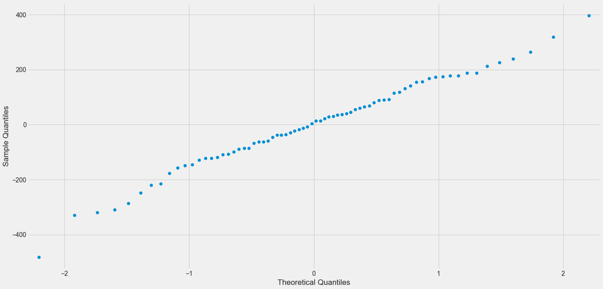

```python
#analyser les résidus
data['residu'] = reg_simp.resid

#Vérifier si la distribution est Normale:

sm.qqplot(data['residu'])
```

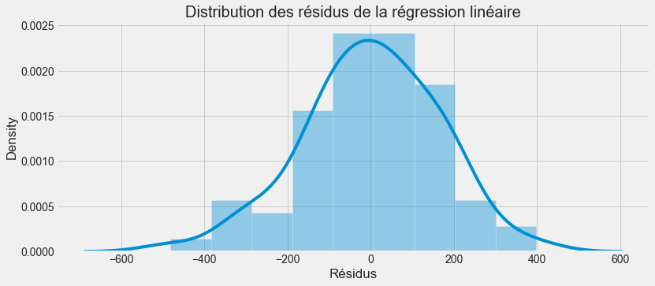

```python
#
fig = plt.figure(figsize=(12,5))
ax = sns.distplot(data.residu)
plt.xlabel('Résidus')
plt.title("Distribution des résidus de la régression linéaire", fontsize=20)
plt.savefig("graphique des residus de  la reg lineaire.png")
plt.show()
```

```python
#Test de Shapiro-Wilk
from scipy.stats import shapiro
shapiro(reg_simp.resid)
```

```
ShapiroResult(statistic=0.9906226992607117, pvalue=0.8743462562561035)
```

Nous obtenons un p valeur superieur au seuil de 5% . On ne peut donc pas rejeter H0 , donc la normalité des residus est validée.

```python
#Recuperons  les  parametrees de  notre  modele
a, b = reg_simp.params
print("a =",a,"| b =",b)
```

```
a = 3000.490741641903 | b = 3.4155587155722826
```

```python
#Creation des données corrigées
data['consommation_corrigée'] = data['consoelect'] - data['dju'] * reg_simp.params['dju']
```

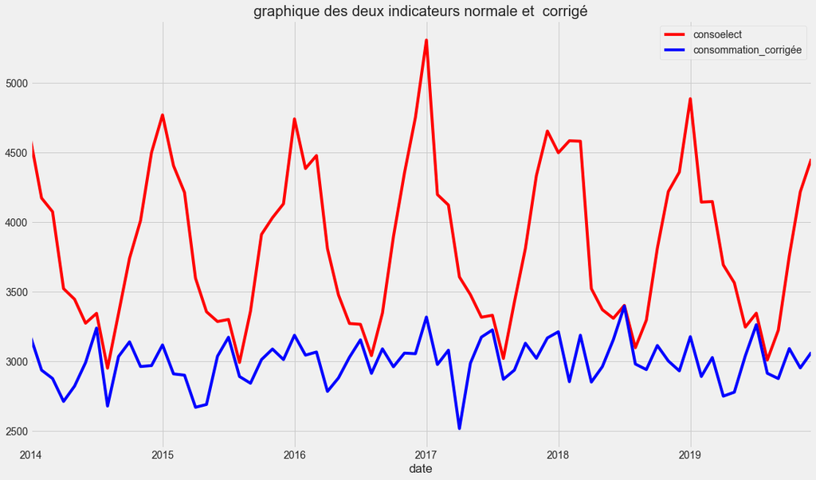

```python
#Affichons le  graphique de correction de  l'effet  temperature
data['consoelect'].plot(figsize = (17,10),x = 'date', color = 'red', legend = True)
data['consommation_corrigée'].plot(legend = True, color = 'blue')
plt.title('graphique des deux indicateurs normale et  corrigé')
plt.savefig('Distributions des  consommations et leurs corrections de variations saisonnieres.jpg')
```

**Interpetation**

La correction de la variation saisonniere peut s'expliquer dans ce cas d'etude comme un moyen de comprendre quel est l'impact de la meteo sur la consommation et la production de l'electricité. Les observation du DJU peuvent s'expliquer comme le deficit à un niveau de temperature de la quantité denergie dont a besoin les familles pour bien vivre. Par exemple on pourrait saisir le DJu comme l'eenrgie qu'il faut pour combler le degre de temperature journalier. Il en faut plus en periode de fraicheur qu'en periode de chaleur comme en été. Nous allons passer maintenant à la question 2 sur la dessaisonnalisation

# Question 2 : desaisonnalisation grace aux moyennes mobiles

On utilise la fonction "seasonal_decompose" du package statsmodels :

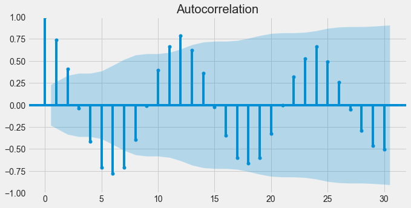

```python
rcParams['figure.figsize'] = 10, 5

from statsmodels.tsa.seasonal import seasonal_decompose


sm.graphics.tsa.plot_acf(data.consoelect.squeeze(), lags=30)
plt.show()
```

frequence annuelle

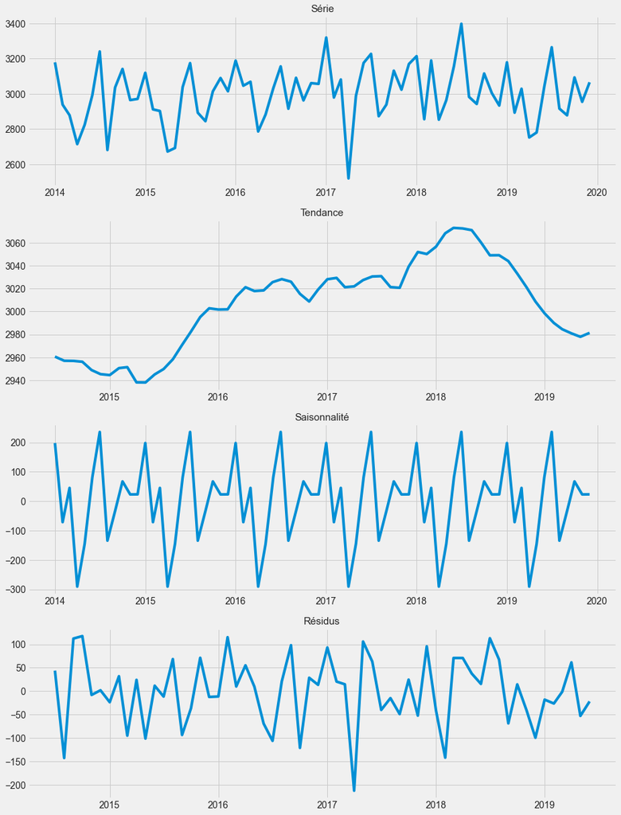

```python
from statsmodels.tsa.seasonal import seasonal_decompose
import matplotlib.pyplot as plt
rcParams['figure.figsize'] = 14, 20
decomposition = seasonal_decompose(data['consommation_corrigée'],  model='additive',period=12)
fig, ax = plt.subplots(4,1)
ax[0].plot(decomposition.observed)
ax[0].set_title('Série', fontsize=15)
ax[1].plot(decomposition.trend)
ax[1].set_title('Tendance', fontsize=15)
ax[2].plot(decomposition.seasonal)
ax[2].set_title('Saisonnalité', fontsize=15)
ax[3].plot(decomposition.resid)
ax[3].set_title('Résidus', fontsize=15)


plt.savefig('decomposition saisonniere.jpg')
plt.show()
```

```python
#Différenciation  avec la saisonnalité pour obtenir une série temporelle hors impact saisonnier.
data['conso_ccd'] = data['consommation_corrigée'] - decomposition.seasonal
```

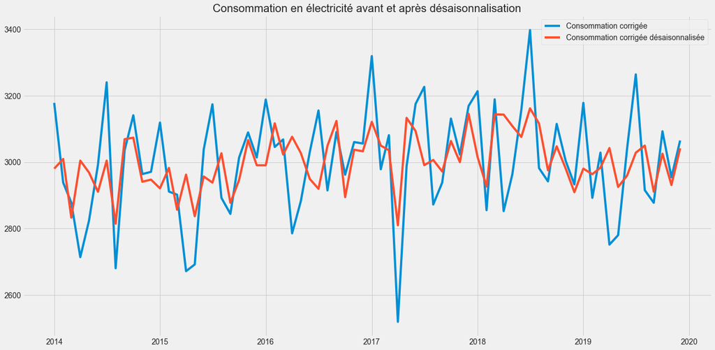

```python
#Visualisation de la consommation d'électricité avant et après l'impact dela désaisonnalisation
rcParams['figure.figsize'] = 20, 10
plt.plot(data['consommation_corrigée'], label='Consommation corrigée')
plt.plot(data['conso_ccd'], label='Consommation corrigée désaisonnalisée')
plt.title('Consommation en électricité avant et après désaisonnalisation')
plt.savefig("conso_corrige_desaisonnalise.png")
plt.legend()
plt.show()
```

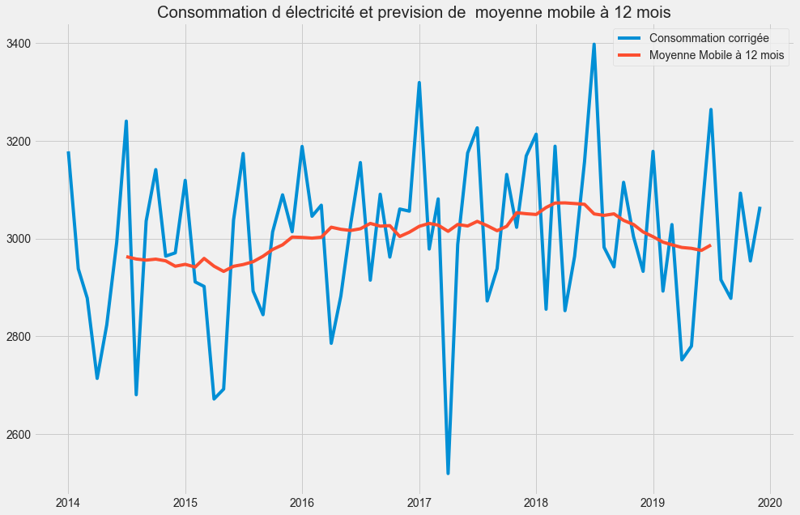

```python
#Visualisation de la consommation en électricité avec moyenne mobile à 12 mois
rcParams['figure.figsize'] = 15, 10
plt.plot(data['consommation_corrigée'], label='Consommation corrigée')
plt.plot(data['consommation_corrigée'].rolling(12, center=True).mean(), label='Moyenne Mobile à 12 mois')


plt.title('Consommation d électricité et prevision de  moyenne mobile à 12 mois')

plt.savefig("conso_corrigée_moyennemobile.png")
plt.legend()
plt.show()
```

# Question 3 : prevision de la consommation grace à differentes methodes

# Avec la methode Holt Winters (lissage exponentiel)

Leur objectif est de prévoir à la date T une série temporelle à un horizon ℓ à partir de T observations

```python
from statsmodels.tsa.api import ExponentialSmoothing
rcParams['figure.figsize'] = 15, 10

y = np.asarray(data["consommation_corrigée"])
hw = ExponentialSmoothing(y, seasonal_periods=12, trend='add', seasonal='add').fit()
hw_pred = hw.forecast(12)
```

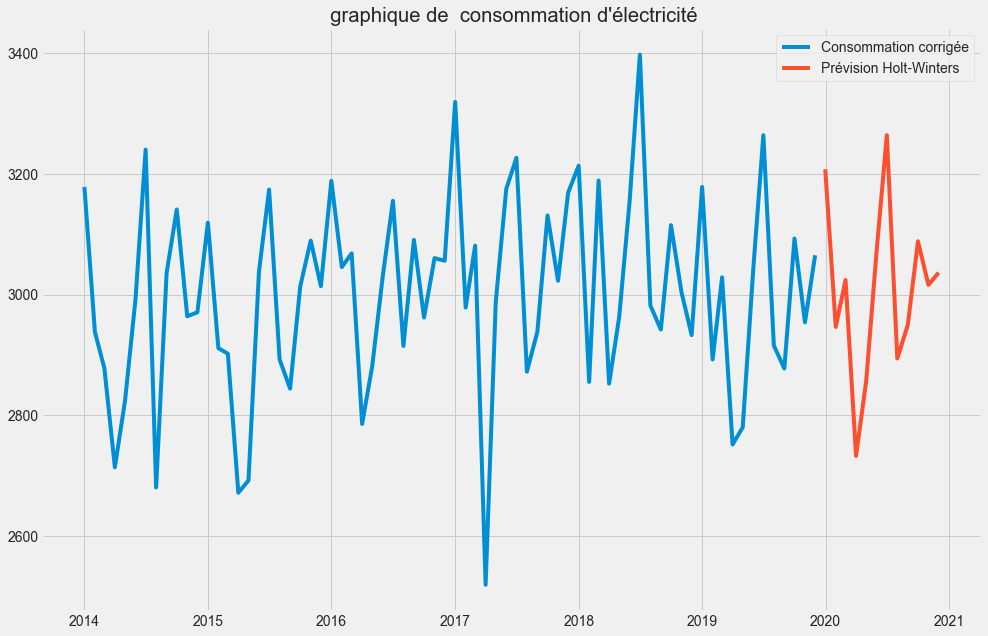

```python
#Visualisation de la prévision à 12 mois par Holt-Winters
plt.plot(data["consommation_corrigée"], label='Consommation corrigée')
plt.plot(pd.date_range(data.index[len(y)-1], periods=12, freq='M'), hw_pred, label='Prévision Holt-Winters')

plt.title("  graphique de  consommation d'électricité ")

plt.savefig("prevision2020_holt-winters.png")
plt.legend()
plt.show()
```

En tenant compte de l'effet temperature selon le deficit qu'il cree , on peut prevoir les observation de l'année 2020 et ensuite verifier celles ci. Nous le faisons ci dessous

[figure not shown]

```python
#Visualisation des années (2019/2020)
plt.plot(data["consommation_corrigée"].iloc[-12:], label='Consommation corrigée')
plt.plot(pd.date_range(data.index[len(y)-1], periods=12, freq='M'), hw_pred, label='Prévision Holt-Winters')

plt.title("Consommation d'électricité en Grand Est  2019 ")

plt.legend()
plt.savefig("prevision_visu20192020_holt-winters.png")
plt.show()
```

Ce graphe indique deux allures de courbes ressemblants;

# Prediction avec holt-winters 2

```python
DUREE_PREDITE = 12
troncature = DUREE_PREDITE

y = data['consommation_corrigée']

y_tronc = y[:-troncature]
y_a_prevoir = y[-troncature:]
```

```python
hw2_model = ExponentialSmoothing(np.asarray(y_tronc), seasonal_periods = 12,
                                 trend = 'additive', seasonal = 'additive').fit()
# prédiction
hw2_pred = hw2_model.forecast(DUREE_PREDITE)
# on ajoute en index les dates correspondantes aux prédictions
hw2_pred = pd.Series(hw2_pred, index = y_a_prevoir.index)
```

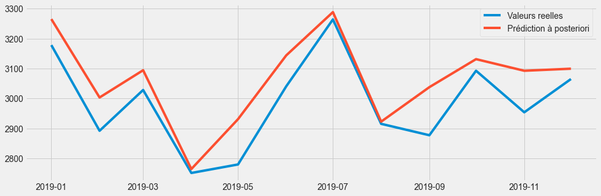

```python
# afficher les n derniers mois
nb_mois = 12
plt.figure(figsize=(15,5))
plt.plot(y[-nb_mois:], label="Valeurs reelles")
plt.plot(hw2_pred.iloc[-nb_mois:], label='Prédiction à posteriori')
plt.legend()
```

**Metrique de controle de la prediction**

```python
mape = round((np.abs(1-hw2_pred/y_a_prevoir)).mean()*100, 2)
mape
```

```
2.64
```

```python
rmse = np.sqrt(((y_a_prevoir-hw2_pred)**2).mean())
rmse
```

```
94.12621942409774
```